# Actividad-6

[figure not shown]

[figure not shown]

[figure not shown]

[figure not shown]

[figure not shown]

[figure not shown]

[figure not shown]

[figure not shown]

# Contexto y Manipulación

## Column1

### **Primer acercamiento a los datos**

#### **Cargando datos**

Cargaremos la data de la siguiente forma:

```
df <-read.csv("C:\\Users\\eduar\\OneDrive - Instituto Tecnologico y de Estudios Superiores de Monterrey\\Tec Monterrey Adm TI M\\4. Analisis y minería de datos para la toma de desiciones\\A6\\Actividad-6\\processed.switzerland.data", header = F)
```

```
Rows: 123
Columns: 14
$ V1  <int> 32, 34, 35, 36, 38, 38, 38, 38, 38, 38, 40, 41, 42, 42, 43, 43, 43…
$ V2  <int> 1, 1, 1, 1, 0, 0, 1, 1, 1, 1, 1, 1, 1, 1, 1, 1, 1, 1, 1, 1, 1, 1, …
$ V3  <int> 1, 4, 4, 4, 4, 4, 3, 3, 4, 4, 4, 4, 4, 4, 4, 4, 4, 3, 4, 4, 3, 3, …
$ V4  <chr> "95", "115", "?", "110", "105", "110", "100", "115", "135", "150",…
$ V5  <int> 0, 0, 0, 0, 0, 0, 0, 0, 0, 0, 0, 0, 0, 0, 0, 0, 0, 0, 0, 0, 0, 0, …
$ V6  <chr> "?", "?", "?", "?", "?", "0", "?", "0", "?", "?", "?", "?", "?", "…
$ V7  <chr> "0", "?", "0", "0", "0", "0", "0", "0", "0", "0", "1", "0", "0", "…
$ V8  <chr> "127", "154", "130", "125", "166", "156", "179", "128", "150", "12…
$ V9  <chr> "0", "0", "1", "1", "0", "0", "0", "1", "0", "1", "0", "0", "1", "…
$ V10 <chr> ".7", ".2", "?", "1", "2.8", "0", "-1.1", "0", "0", "?", "0", "1.6…
$ V11 <chr> "1", "1", "?", "2", "1", "2", "1", "2", "?", "?", "1", "1", "3", "…
$ V12 <chr> "?", "?", "?", "?", "?", "?", "?", "?", "?", "?", "?", "?", "?", "…
$ V13 <chr> "?", "?", "7", "6", "?", "3", "?", "7", "3", "3", "?", "?", "?", "…
$ V14 <int> 1, 1, 3, 1, 2, 1, 0, 1, 2, 1, 2, 2, 1, 2, 3, 4, 2, 0, 1, 1, 1, 3, …
```

#### **Entendiendo el contexto de los datos**

Publication Request:

>>>>>>>>>>>>>>>>>>>>>>>>>>>>>>>>>>>>>>>>>>>>>>>>>>>>>>>>>>>>>>>>>>>>>>

This file describes the contents of the heart-disease directory.

This directory contains 4 databases concerning heart disease diagnosis.

All attributes are numeric-valued. The data was collected from the

four following locations:

1. Cleveland Clinic Foundation (cleveland.data)
2. Hungarian Institute of Cardiology, Budapest (hungarian.data)
3. V.A. Medical Center, Long Beach, CA (long-beach-va.data)
4. University Hospital, Zurich, Switzerland (switzerland.data)

Each database has the same instance format. While the databases have 76

raw attributes, only 14 of them are actually used. Thus I’ve taken the

liberty of making 2 copies of each database: one with all the attributes

and 1 with the 14 attributes actually used in past experiments.

The authors of the databases have requested:

…that any publications resulting from the use of the data include the

names of the principal investigator responsible for the data collection

at each institution. They would be:

1. Hungarian Institute of Cardiology. Budapest: Andras Janosi, M.D.
2. University Hospital, Zurich, Switzerland: William Steinbrunn, M.D.
3. University Hospital, Basel, Switzerland: Matthias Pfisterer, M.D.
4. V.A. Medical Center, Long Beach and Cleveland Clinic Foundation:

   Robert Detrano, M.D., Ph.D.

Thanks in advance for abiding by this request.

David Aha

July 22, 1988

>>>>>>>>>>>>>>>>>>>>>>>>>>>>>>>>>>>>>>>>>>>>>>>>>>>>>>>>>>>>>>>>>>>>>>

1. Title: Heart Disease Databases

2. Source Information:

1. Creators:

-- 1. Hungarian Institute of Cardiology. Budapest: Andras Janosi, M.D.

-- 2. University Hospital, Zurich, Switzerland: William Steinbrunn, M.D.

-- 3. University Hospital, Basel, Switzerland: Matthias Pfisterer, M.D.

-- 4. V.A. Medical Center, Long Beach and Cleveland Clinic Foundation:

Robert Detrano, M.D., Ph.D.

2. Donor: David W. Aha (aha@ics.uci.edu) (714) 856-8779
3. Date: July, 1988

3. Past Usage:

1. Detrano,~R., Janosi,~A., Steinbrunn,~W., Pfisterer,~M., Schmid,~J.,

Sandhu,~S., Guppy,~K., Lee,~S., \& Froelicher,~V. (1989). {\it

International application of a new probability algorithm for the

diagnosis of coronary artery disease.} {\it American Journal of

Cardiology}, {\it 64},304–310.

-- International Probability Analysis

-- Address: Robert Detrano, M.D.

Cardiology 111-C

V.A. Medical Center

5901 E. 7th Street

Long Beach, CA 90028

-- Results in percent accuracy: (for 0.5 probability threshold)

Data Name: CDF CADENZA

-- Hungarian 77 74

Long beach 79 77

Swiss 81 81

-- Approximately a 77% correct classification accuracy with a

logistic-regression-derived discriminant function

2. David W. Aha & Dennis Kibler

--

-- Instance-based prediction of heart-disease presence with the

Cleveland database

-- NTgrowth: 77.0% accuracy

-- C4: 74.8% accuracy

3. John Gennari

-- Gennari, J.~H., Langley, P, \& Fisher, D. (1989). Models of

incremental concept formation. {\it Artificial Intelligence, 40},

11–61.

-- Results:

-- The CLASSIT conceptual clustering system achieved a 78.9% accuracy

on the Cleveland database.

4. Relevant Information:

This database contains 76 attributes, but all published experiments

refer to using a subset of 14 of them. In particular, the Cleveland

database is the only one that has been used by ML researchers to

this date. The “goal” field refers to the presence of heart disease

in the patient. It is integer valued from 0 (no presence) to 4.

Experiments with the Cleveland database have concentrated on simply

attempting to distinguish presence (values 1,2,3,4) from absence (value

0).

The names and social security numbers of the patients were recently

removed from the database, replaced with dummy values.

One file has been “processed”, that one containing the Cleveland

database. All four unprocessed files also exist in this directory.

5. Number of Instances:

Database: # of instances:

Cleveland: 303

Hungarian: 294

Switzerland: 123

Long Beach VA: 200

6. Number of Attributes: 76 (including the predicted attribute)

7. Attribute Information:

-- Only 14 used

-- 1. #3 (age)

-- 2. #4 (sex)

-- 3. #9 (cp)

-- 4. #10 (trestbps)

-- 5. #12 (chol)

-- 6. #16 (fbs)

-- 7. #19 (restecg)

-- 8. #32 (thalach)

-- 9. #38 (exang)

-- 10. #40 (oldpeak)

-- 11. #41 (slope)

-- 12. #44 (ca)

-- 13. #51 (thal)

-- 14. #58 (num) (the predicted attribute)

-- Complete attribute documentation:

1 id: patient identification number

2 ccf: social security number (I replaced this with a dummy value of 0)

3 age: age in years

4 sex: sex (1 = male; 0 = female)

5 painloc: chest pain location (1 = substernal; 0 = otherwise)

6 painexer (1 = provoked by exertion; 0 = otherwise)

7 relrest (1 = relieved after rest; 0 = otherwise)

8 pncaden (sum of 5, 6, and 7)

9 cp: chest pain type

-- Value 1: typical angina

-- Value 2: atypical angina

-- Value 3: non-anginal pain

-- Value 4: asymptomatic

10 trestbps: resting blood pressure (in mm Hg on admission to the

hospital)

11 htn

12 chol: serum cholestoral in mg/dl

13 smoke: I believe this is 1 = yes; 0 = no (is or is not a smoker)

14 cigs (cigarettes per day)

15 years (number of years as a smoker)

16 fbs: (fasting blood sugar > 120 mg/dl) (1 = true; 0 = false)

17 dm (1 = history of diabetes; 0 = no such history)

18 famhist: family history of coronary artery disease (1 = yes; 0 = no)

19 restecg: resting electrocardiographic results

-- Value 0: normal

-- Value 1: having ST-T wave abnormality (T wave inversions and/or ST

elevation or depression of > 0.05 mV)

-- Value 2: showing probable or definite left ventricular hypertrophy

by Estes’ criteria

20 ekgmo (month of exercise ECG reading)

21 ekgday(day of exercise ECG reading)

22 ekgyr (year of exercise ECG reading)

23 dig (digitalis used furing exercise ECG: 1 = yes; 0 = no)

24 prop (Beta blocker used during exercise ECG: 1 = yes; 0 = no)

25 nitr (nitrates used during exercise ECG: 1 = yes; 0 = no)

26 pro (calcium channel blocker used during exercise ECG: 1 = yes; 0 = no)

27 diuretic (diuretic used used during exercise ECG: 1 = yes; 0 = no)

28 proto: exercise protocol

1 = Bruce

2 = Kottus

3 = McHenry

4 = fast Balke

5 = Balke

6 = Noughton

7 = bike 150 kpa min/min (Not sure if “kpa min/min” is what was

written!)

8 = bike 125 kpa min/min

9 = bike 100 kpa min/min

10 = bike 75 kpa min/min

11 = bike 50 kpa min/min

12 = arm ergometer

29 thaldur: duration of exercise test in minutes

30 thaltime: time when ST measure depression was noted

31 met: mets achieved

32 thalach: maximum heart rate achieved

33 thalrest: resting heart rate

34 tpeakbps: peak exercise blood pressure (first of 2 parts)

35 tpeakbpd: peak exercise blood pressure (second of 2 parts)

36 dummy

37 trestbpd: resting blood pressure

38 exang: exercise induced angina (1 = yes; 0 = no)

39 xhypo: (1 = yes; 0 = no)

40 oldpeak = ST depression induced by exercise relative to rest

41 slope: the slope of the peak exercise ST segment

-- Value 1: upsloping

-- Value 2: flat

-- Value 3: downsloping

42 rldv5: height at rest

43 rldv5e: height at peak exercise

44 ca: number of major vessels (0-3) colored by flourosopy

45 restckm: irrelevant

46 exerckm: irrelevant

47 restef: rest raidonuclid (sp?) ejection fraction

48 restwm: rest wall (sp?) motion abnormality

0 = none

1 = mild or moderate

2 = moderate or severe

3 = akinesis or dyskmem (sp?)

49 exeref: exercise radinalid (sp?) ejection fraction

50 exerwm: exercise wall (sp?) motion

51 thal: 3 = normal; 6 = fixed defect; 7 = reversable defect

52 thalsev: not used

53 thalpul: not used

54 earlobe: not used

55 cmo: month of cardiac cath (sp?) (perhaps “call”)

56 cday: day of cardiac cath (sp?)

57 cyr: year of cardiac cath (sp?)

58 num: diagnosis of heart disease (angiographic disease status)

-- Value 0: < 50% diameter narrowing

-- Value 1: > 50% diameter narrowing

(in any major vessel: attributes 59 through 68 are vessels)

59 lmt

60 ladprox

61 laddist

62 diag

63 cxmain

64 ramus

65 om1

66 om2

67 rcaprox

68 rcadist

69 lvx1: not used

70 lvx2: not used

71 lvx3: not used

72 lvx4: not used

73 lvf: not used

74 cathef: not used

75 junk: not used

76 name: last name of patient

```
(I replaced this with the dummy string "name")
```

9. Missing Attribute Values: Several. Distinguished with value -9.0.

10. Class Distribution:

Database: 0 1 2 3 4 Total

Cleveland: 164 55 36 35 13 303

Hungarian: 188 37 26 28 15 294

Switzerland: 8 48 32 30 5 123

Long Beach VA: 51 56 41 42 10 200

Como se puede ver el nombre de las columnas es por lo tanto:

V1: “Age”

V2: “Sex”

V3: “Chest_Pain_Type”

V4: “Resting_Blood_Pressure”

V5: “Serum_Cholesterol”

V6: “Fasting_Blood_Sugar”

V7: “Resting_ECG”

V8: “Max_Heart_Rate_Achieved”

V9: “Exercise_Induced_Angina”

V10: “ST_Depression_Exercise”

V11: “Peak_Exercise_ST_Segment”

V12: “Num_Major_Vessels_Flouro”

V13: “Thalassemia”

V14: “Diagnosis_Heart_Disease”

Suponemos que existen más columnas dentro de esta base de datos que no fueron proporcionadas por ejemplo:

- ccf: social security number
- relrest (1 = relieved after rest; 0 = otherwise)
- pncaden (sum of 5, 6, and 7)
- Otras más

#### **Comprendiendo las columnas**

1. **Age**: Edad del sujeto
2. **Sex**: Género del sujeto
   - 0 = femenino
   - 1 = masculino
3. **Chest-pain type**: Tipo de dolor torácico experimentado por el individuo:
   - 1 = angina típica
   - 2 = angina atípica
   - 3 = dolor no anginoso
   - 4 = angina asintomática
4. **Resting Blood Pressure**: presión arterial en reposo en mm Hg (admisión al hospital)
5. **Serum Cholesterol**: Colesterol sérico en mg/dl
6. **Fasting Blood Sugar**: nivel de azúcar en sangre en ayunas (120 mg/dl):
   - 0 = azúcar en sangre en ayunas <= 120 mg/dl
   - 1 = azúcar en sangre en ayunas > 120 mg/dl
7. **Resting ECG**: resultados electrocardiográficos en reposo
   - 0 = normales
   - 1 = anormalidad de la onda ST-T (Inversiones de la onda T y/o elevación o depresión del ST > 0,05 mV)
   - 2 = que muestra hipertrofia ventricular izquierdo probable o definitiva según los criterios de Este’s
8. **Maximum Heart Rate Achieved**: frecuencia cardíaca máxima del sujeto
9. **Exercise Induced Angina**:
   - 0 = no
   - 1 = sí
10. **ST Depression Induced by Exercise Relative to Rest**: depresión del ST inducida por el ejercicio en relación con el reposo
11. **Peak Exercise ST Segmen**t: la pendiente del segmento ST de ejercicio máximo
    - 1 = pendiente ascendente
    - 2 = plano
    - 3 = pendiente descendente
12. **Number of Major Vessels (0-3) Visible on Flouroscopy**: número de vasos visibles bajo fluoroscopia (0-3)
13. **Thal**: Sabra dios :(
    - 3 = normales
    - 6 = defecto fijo
    - 7 = defecto reversible
14. **Diagnosis of Heart Disease**: diagnóstico de enfermedad cardíaca (estado de enfermedad angiográfico):
    - Valor 0: < 50% estrechamiento del diámetro
    - Valor 1: > 50% estrechamiento del diámetro
    - (en cualquier buque principal: los atributos 59 a 68 son buques)
    - ¿Se entiende que si es 0 no hay enfermedad?

El atributo a predecir es **Diagnosis of Heart Disease**

#### Modificando el nombre de las columnas

| Age | Sex | Chest Pain Type | Resting Blood Pressure | Serum Cholesterol | Fasting Blood Sugar | Resting ECG | Max Heart Rate Achieved | Exercise Induced Angina | ST Depression Exercise | Peak Exercise ST Segment | Num Major Vessels Flouro | Thal | Diagnosis Heart Disease |
| --- | --- | --- | --- | --- | --- | --- | --- | --- | --- | --- | --- | --- | --- |
| 32 | 1 | 1 | 95 | 0 | ? | 0 | 127 | 0 | .7 | 1 | ? | ? | 1 |
| 34 | 1 | 4 | 115 | 0 | ? | ? | 154 | 0 | .2 | 1 | ? | ? | 1 |
| 35 | 1 | 4 | ? | 0 | ? | 0 | 130 | 1 | ? | ? | ? | 7 | 3 |
| 36 | 1 | 4 | 110 | 0 | ? | 0 | 125 | 1 | 1 | 2 | ? | 6 | 1 |
| 38 | 0 | 4 | 105 | 0 | ? | 0 | 166 | 0 | 2.8 | 1 | ? | ? | 2 |
| 38 | 0 | 4 | 110 | 0 | 0 | 0 | 156 | 0 | 0 | 2 | ? | 3 | 1 |
| 38 | 1 | 3 | 100 | 0 | ? | 0 | 179 | 0 | -1.1 | 1 | ? | ? | 0 |
| 38 | 1 | 3 | 115 | 0 | 0 | 0 | 128 | 1 | 0 | 2 | ? | 7 | 1 |
| 38 | 1 | 4 | 135 | 0 | ? | 0 | 150 | 0 | 0 | ? | ? | 3 | 2 |
| 38 | 1 | 4 | 150 | 0 | ? | 0 | 120 | 1 | ? | ? | ? | 3 | 1 |

## Column2

### **Limpieza**

Para empezar tenemos un monton de datos con signos de interrogación, veamos cuanto N/A tenemos con la función

`sum(is.na(df))`

```
[1] 0
```

Al menos no tenemos NA.

Sin embargo, tenemos un chorro de valores “?”, por ejemplo:

- -- 5. #12 chol: serum cholestoral in mg/dl
  - Esta varible no contiene mas que ceros, a pesar de que debe de estar medida en mg/dl
- -- 6. #16 fbs: (fasting blood sugar > 120 mg/dl) (1 = true; 0 = false)
  - Esta varible contienen en su gran mayoria signos de interrogación
- -- 12. #44 (ca): ca: number of major vessels (0-3) colored by flourosopy
  - Salvo por 5 observaciones, todas son signos de interrogación.

Por lo que, apesar que creemos que son importantes, tendremos que eliminar estas columnas ya que no nos aportan valor, y rellenar podría a llevar a conjeturas erroneas.

También queremos saber el número de observaciones en la columna de la variable objetivo para comprender si el conjunto de datos está relativamente equilibrado.

| Diagnosis Heart Disease | n |
| --- | --- |
| 0 | 8 |
| 1 | 48 |
| 2 | 32 |
| 3 | 30 |
| 4 | 5 |

Los datos estan claramente desvalanceados, existen muchos más enfermos

### Transformación

Según el analisis anterior que realizamos de la columna objetivo indicamos que:

- **Diagnosis of Heart Disease**: diagnóstico de enfermedad cardíaca (estado de enfermedad angiográfico):
  - Valor 0: < 50% estrechamiento del diámetro
  - Valor 1: > 50% estrechamiento del diámetro
  - (en cualquier buque principal: los atributos 59 a 68 son buques)
  - ¿Se entiende que si es 0 no hay enfermedad?

Mantendremos esta relación y todos los valores que sean por arriba de 0 serán 1 por lo tanto:

- **Diagnosis of Heart Disease**: diagnóstico de enfermedad cardíaca (estado de enfermedad angiográfico):
  - Valor 0: No hay enfermedad
  - Valor 1: Hay enfermedad

Además mutaremos las variables para trabajarlas como factores y eliminaremos las columnas que no aportan (5,6,12), así como combertiremos en NA aquellas observaciones con `?` para despues tirarlas

| Age | Sex | Chest Pain Type | Resting Blood Pressure | Resting ECG | Max Heart Rate Achieved | Exercise Induced Angina | ST Depression Exercise | Peak Exercise ST Segment | Thal | Diagnosis Heart Disease |
| --- | --- | --- | --- | --- | --- | --- | --- | --- | --- | --- |
| 36 | 1 | 4 | 110 | 0 | 125 | 1 | 1.0 | 2 | 6 | 1 |
| 38 | 0 | 4 | 110 | 0 | 156 | 0 | 0.0 | 2 | 3 | 1 |
| 38 | 1 | 3 | 115 | 0 | 128 | 1 | 0.0 | 2 | 7 | 1 |
| 43 | 1 | 4 | 115 | 0 | 145 | 1 | 2.0 | 2 | 7 | 1 |
| 43 | 1 | 4 | 140 | 1 | 140 | 1 | 0.5 | 1 | 7 | 1 |
| 46 | 1 | 4 | 115 | 0 | 113 | 1 | 1.5 | 2 | 7 | 1 |
| 47 | 1 | 3 | 155 | 0 | 118 | 1 | 1.0 | 2 | 3 | 1 |
| 47 | 1 | 4 | 160 | 0 | 124 | 1 | 0.0 | 2 | 7 | 1 |
| 48 | 1 | 4 | 115 | 0 | 128 | 0 | 0.0 | 2 | 6 | 1 |
| 50 | 1 | 4 | 115 | 0 | 120 | 1 | 0.5 | 2 | 6 | 1 |
| 50 | 1 | 4 | 120 | 1 | 156 | 1 | 0.0 | 1 | 6 | 1 |
| 51 | 1 | 4 | 120 | 0 | 104 | 0 | 0.0 | 2 | 3 | 1 |
| 51 | 1 | 4 | 140 | 0 | 60 | 0 | 0.0 | 2 | 3 | 1 |
| 52 | 1 | 4 | 130 | 0 | 120 | 0 | 0.0 | 2 | 7 | 1 |
| 52 | 1 | 4 | 135 | 0 | 128 | 1 | 2.0 | 2 | 7 | 1 |
| 52 | 1 | 4 | 165 | 0 | 122 | 1 | 1.0 | 1 | 7 | 1 |
| 53 | 1 | 2 | 120 | 0 | 95 | 0 | 0.0 | 2 | 3 | 1 |
| 53 | 1 | 3 | 105 | 0 | 115 | 0 | 0.0 | 2 | 7 | 1 |
| 53 | 1 | 4 | 120 | 0 | 120 | 0 | 0.0 | 2 | 7 | 1 |
| 53 | 1 | 4 | 130 | 2 | 135 | 1 | 1.0 | 2 | 7 | 1 |
| 54 | 1 | 4 | 120 | 0 | 155 | 0 | 0.0 | 2 | 7 | 1 |
| 54 | 1 | 4 | 130 | 0 | 110 | 1 | 3.0 | 2 | 7 | 1 |
| 54 | 1 | 4 | 180 | 0 | 150 | 0 | 1.5 | 2 | 7 | 1 |
| 55 | 1 | 4 | 120 | 1 | 92 | 0 | 0.3 | 1 | 7 | 1 |
| 55 | 1 | 4 | 140 | 0 | 83 | 0 | 0.0 | 2 | 7 | 1 |
| 56 | 1 | 3 | 120 | 0 | 97 | 0 | 0.0 | 2 | 7 | 0 |
| 56 | 1 | 3 | 125 | 0 | 98 | 0 | -2.0 | 2 | 7 | 1 |
| 56 | 1 | 3 | 155 | 1 | 99 | 0 | 0.0 | 2 | 3 | 1 |
| 56 | 1 | 4 | 120 | 1 | 100 | 1 | -1.0 | 3 | 7 | 1 |
| 56 | 1 | 4 | 125 | 0 | 103 | 1 | 1.0 | 2 | 7 | 1 |
| 57 | 1 | 4 | 140 | 0 | 120 | 1 | 2.0 | 2 | 6 | 1 |
| 57 | 1 | 4 | 160 | 0 | 98 | 1 | 2.0 | 2 | 7 | 1 |
| 58 | 1 | 4 | 130 | 1 | 100 | 1 | 1.0 | 2 | 6 | 1 |
| 59 | 1 | 4 | 120 | 0 | 115 | 0 | 0.0 | 2 | 3 | 1 |
| 59 | 1 | 4 | 135 | 0 | 115 | 1 | 1.0 | 2 | 7 | 1 |
| 60 | 1 | 4 | 135 | 0 | 63 | 1 | 0.5 | 1 | 7 | 1 |
| 60 | 1 | 4 | 160 | 1 | 99 | 1 | 0.5 | 2 | 7 | 1 |
| 61 | 1 | 4 | 125 | 0 | 105 | 1 | 0.0 | 3 | 7 | 1 |
| 61 | 1 | 4 | 130 | 2 | 115 | 0 | 0.0 | 2 | 7 | 1 |
| 61 | 1 | 4 | 150 | 0 | 105 | 1 | 0.0 | 2 | 7 | 1 |
| 61 | 1 | 4 | 150 | 0 | 117 | 1 | 2.0 | 2 | 7 | 1 |
| 61 | 1 | 4 | 160 | 1 | 145 | 0 | 1.0 | 2 | 7 | 1 |
| 62 | 1 | 3 | 160 | 0 | 72 | 1 | 0.0 | 2 | 3 | 1 |
| 62 | 1 | 4 | 115 | 0 | 72 | 1 | -0.5 | 2 | 3 | 1 |
| 62 | 1 | 4 | 150 | 1 | 78 | 0 | 2.0 | 2 | 7 | 1 |
| 63 | 1 | 4 | 185 | 0 | 98 | 1 | 0.0 | 1 | 7 | 1 |
| 64 | 0 | 4 | 200 | 0 | 140 | 1 | 1.0 | 2 | 3 | 1 |
| 65 | 1 | 4 | 115 | 0 | 93 | 1 | 0.0 | 2 | 7 | 1 |
| 66 | 1 | 4 | 150 | 0 | 108 | 1 | 2.0 | 2 | 7 | 1 |
| 67 | 1 | 1 | 145 | 2 | 125 | 0 | 0.0 | 2 | 3 | 1 |
| 68 | 1 | 4 | 135 | 1 | 120 | 1 | 0.0 | 1 | 7 | 1 |
| 69 | 1 | 4 | 135 | 0 | 130 | 0 | 0.0 | 2 | 6 | 1 |
| 70 | 1 | 4 | 115 | 1 | 92 | 1 | 0.0 | 2 | 7 | 1 |
| 70 | 1 | 4 | 140 | 0 | 157 | 1 | 2.0 | 2 | 7 | 1 |
| 73 | 0 | 3 | 160 | 1 | 121 | 0 | 0.0 | 1 | 3 | 1 |

Como se puede ver quedarón solo 55 observaciones y se eliminaron columnas que creemos pudieron haber sido interesantes analisar, sin embargo, como se consulto con el Dr. Diógenes Alexander Garrido, no se consultaran estos atributos

Recordando un poco de estadistica, según el teorema del limite central tenemos suficientes datos para poder aproximar a la población, sin embargo, un analisis cercano a big data o minería de datos queda corto.

Esta parte fue un poco dificil de llevar a cabo y sentimos que realmente estamos perdiendo mucha información.

# Análisis

## Column1

Evaluaremos algunas relaciones con la variable objetivo. Cada grafico estara descrito en la parte inferior.

### **boxplot**

#### **Diagnostivos vs Edad (dfc)**

Como se puede apreciar, debido a que se dejaron ir todas aquellas observacioens con ‘`?'` nuestros datos se redujeron demasiado y la población no enferma (0) se redujeron considerablemente hasta el punto en que solo tenemos una sola observación. :’(

Pensabamos realizar más analisis con esta data “limpia” sin embargo, nos arriesgaremos a usar la data con nulos `dfh`

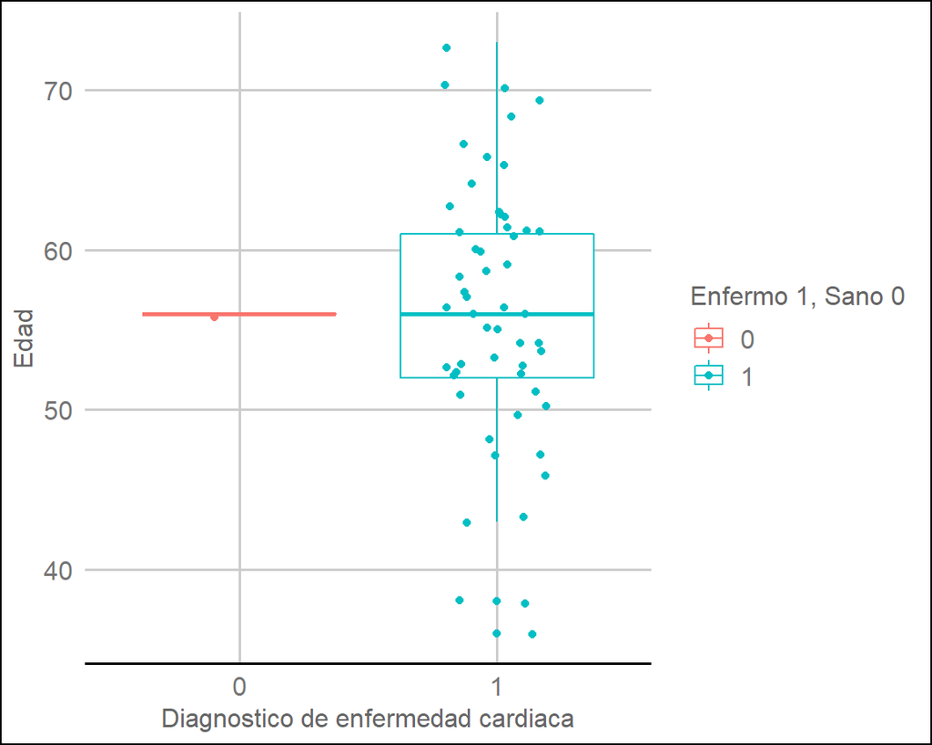

#### **Diagnostivos vs Edad (dfh)**

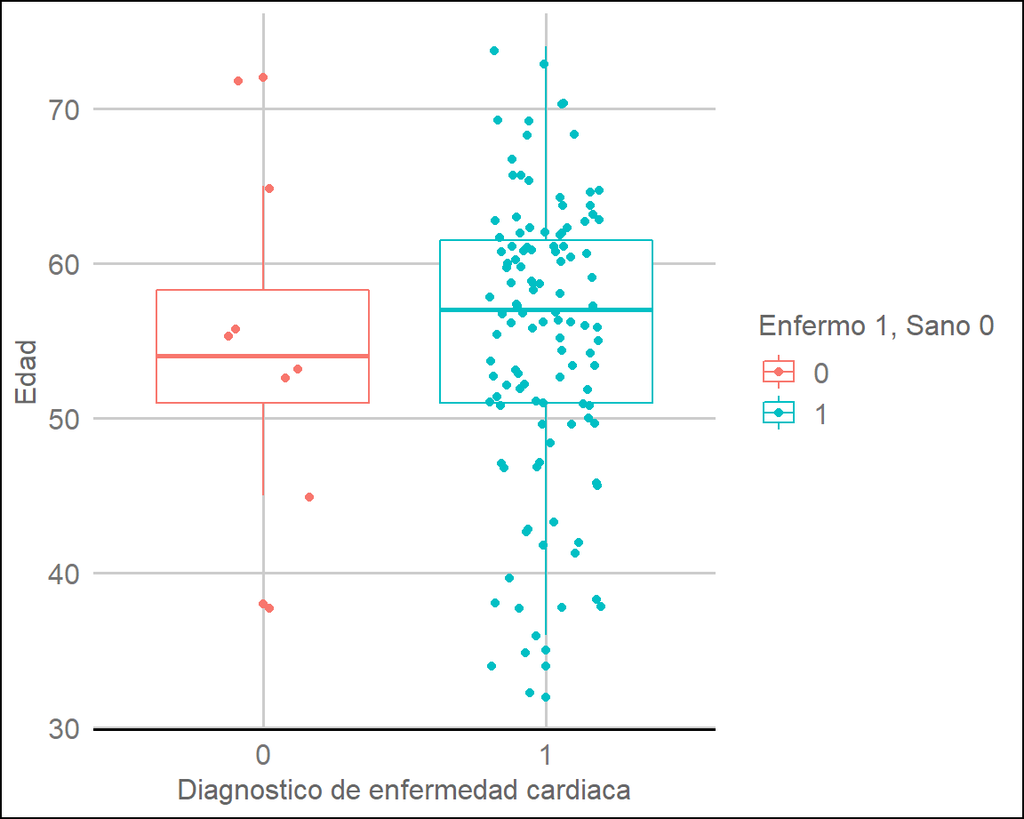

#### **Diagnostivos vs Edad (por sexo)**

Como podemos observar, no existen mujeres sanas, por otro lado las mujeres que más enferman tienen a tener mayor edad que los hombres, además de que aparentemente existe un sesgo ya que la mediana se acerca más al tercer cuartil.

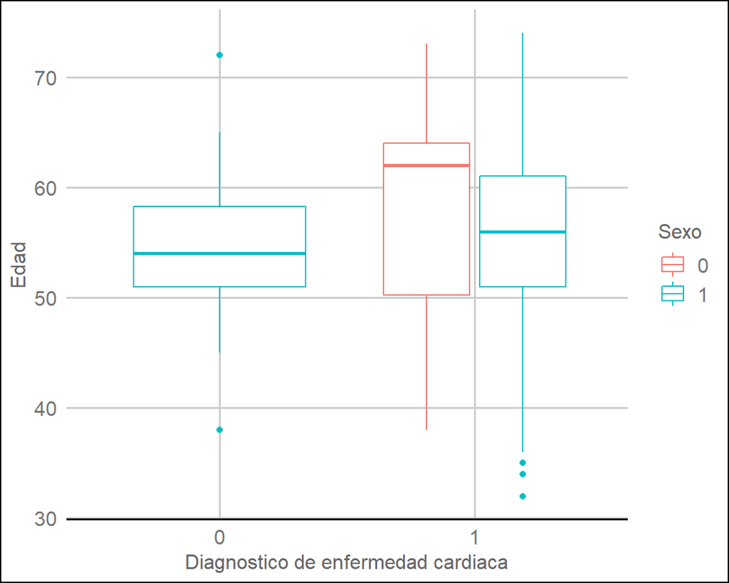

#### **Diagnostivos vs Edad (tipos de dolor)**

Podemos ver que los que llegaron al hospital experimentaban dolores como “dolor no anginoso”, “angina asintomática” y muy pocos casos de “angina atípica”.

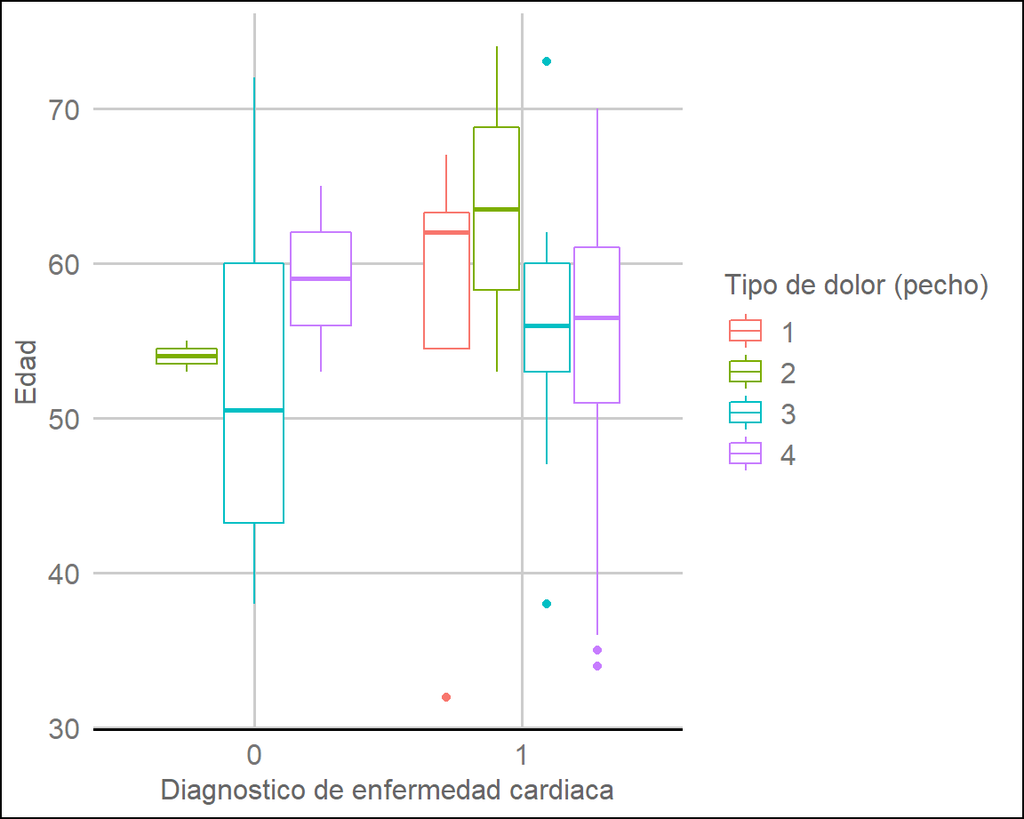

#### **Diagnostivos vs Edad (pendiente ST ejercicio Max)**

Esta no la pudimos interpretar pero un cardiologo podría obtener información que le pueda ser de utilidad.

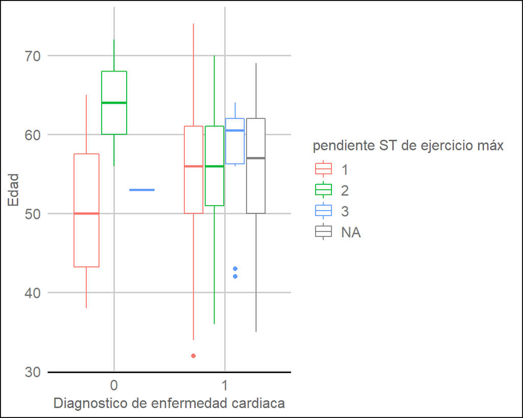

## Column2

### Correlación y balance

#### **Pearson**

Crearemos una matriz de correlación con el método de Pearson sin embargo, esta base de datos tiene un excendete de valores sesgados por lo que también estaremos usando el método de Kendall

```
                                Age Resting_Blood_Pressure
Age                      1.00000000             0.36394744
Resting_Blood_Pressure   0.36394744             1.00000000
Max_Heart_Rate_Achieved -0.25988609             0.02021897
ST_Depression_Exercise  -0.03219504             0.25458948
Thal                    -0.02213109            -0.10694451
                        Max_Heart_Rate_Achieved ST_Depression_Exercise
Age                                 -0.25988609            -0.03219504
Resting_Blood_Pressure               0.02021897             0.25458948
Max_Heart_Rate_Achieved              1.00000000             0.22328465
ST_Depression_Exercise               0.22328465             1.00000000
Thal                                 0.12484944             0.24057602
                               Thal
Age                     -0.02213109
Resting_Blood_Pressure  -0.10694451
Max_Heart_Rate_Achieved  0.12484944
ST_Depression_Exercise   0.24057602
Thal                     1.00000000
```

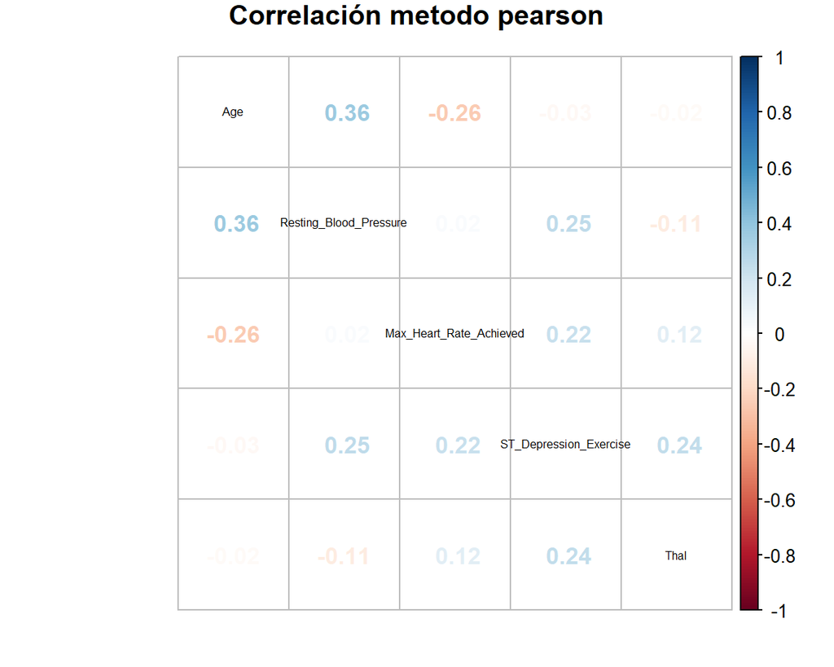

#### **Kendall**

```
                                Age Resting_Blood_Pressure
Age                      1.00000000             0.30385195
Resting_Blood_Pressure   0.30385195             1.00000000
Max_Heart_Rate_Achieved -0.20041700             0.01206703
ST_Depression_Exercise  -0.05253703             0.22663641
Thal                     0.02947812             0.02344036
                        Max_Heart_Rate_Achieved ST_Depression_Exercise
Age                                 -0.20041700            -0.05253703
Resting_Blood_Pressure               0.01206703             0.22663641
Max_Heart_Rate_Achieved              1.00000000             0.17937257
ST_Depression_Exercise               0.17937257             1.00000000
Thal                                -0.01135582             0.22024489
                               Thal
Age                      0.02947812
Resting_Blood_Pressure   0.02344036
Max_Heart_Rate_Achieved -0.01135582
ST_Depression_Exercise   0.22024489
Thal                     1.00000000
```

[figure not shown]

Existen algunas diferencias insignificativas, lo importante de este análisis es observar que ninguna de las variables pareciese estar correlacionada significativamente. Por lo que podemos estar tranquilos y no eliminar más columnas

#### **Balance**

Ya sabemos, a ojo de buen cubero, que nuestros datos no estan balanceados pero haremos el análisis de cada variable.

#### **Diagnostico y sexo**

```
                       Sex
Diagnosis_Heart_Disease  0  1
                      0  0  1
                      1  3 51
```

#### Diagnostico y dolor de pecho

```
                       Chest_Pain_Type
Diagnosis_Heart_Disease  1  2  3  4
                      0  0  0  1  0
                      1  1  1  7 45
```

#### Diagnostico y electro en reposo

```
                       Resting_ECG
Diagnosis_Heart_Disease  ?  0  1  2
                      0  0  1  0  0
                      1  0 39 12  3
```

```
                       Exercise_Induced_Angina
Diagnosis_Heart_Disease  ?  0  1
                      0  0  1  0
                      1  0 21 33
```

#### Diagnostico y Peak Exercise ST Segment

```
                       Peak_Exercise_ST_Segment
Diagnosis_Heart_Disease  ?  1  2  3
                      0  0  0  1  0
                      1  0  8 44  2
```

La mayoría de nuestras columnas estan desproporcionadas. T_T

# Modelo

### Modelo

#### Inicio

Se penso en dividir nuestros datos en training y testin, pero con 55 observaciones no vale la pena, por lo que aplicaremos el modelo y lo analizaremos.

```
Call:
glm(formula = Diagnosis_Heart_Disease ~ ., family = quasibinomial,
    data = dfc)

Deviance Residuals:
       Min          1Q      Median          3Q         Max
-3.386e-05   2.100e-08   2.100e-08   6.090e-07   3.327e-05

Coefficients:
                           Estimate Std. Error t value Pr(>|t|)
(Intercept)               169.56392   42.74201   3.967 0.000294 ***
Age                        -1.86239    0.69753  -2.670 0.010911 *
Sex1                       53.04647    5.78360   9.172 2.20e-11 ***
Chest_Pain_Type2          -49.80215    6.58024  -7.568 3.07e-09 ***
Chest_Pain_Type3          -20.71370    4.98303  -4.157 0.000165 ***
Chest_Pain_Type4           59.15288    6.32286   9.355 1.27e-11 ***
Resting_Blood_Pressure     -0.99153    0.08435 -11.755 1.50e-14 ***
Resting_ECG1               77.33242    3.79159  20.396  < 2e-16 ***
Resting_ECG2              -35.83130    7.07914  -5.062 9.73e-06 ***
Max_Heart_Rate_Achieved     1.22969    0.05736  21.437  < 2e-16 ***
Exercise_Induced_Angina1   52.48834    1.71440  30.616  < 2e-16 ***
ST_Depression_Exercise    -24.13400    0.43887 -54.991  < 2e-16 ***
Peak_Exercise_ST_Segment2   9.98196    2.94629   3.388 0.001592 **
Peak_Exercise_ST_Segment3 -71.11725    4.53786 -15.672  < 2e-16 ***
Thal                      -18.45166    0.43710 -42.213  < 2e-16 ***
---
Signif. codes:  0 '***' 0.001 '**' 0.01 '*' 0.05 '.' 0.1 ' ' 1

(Dispersion parameter for quasibinomial family taken to be 1.118424e-10)

    Null deviance: 9.9964e+00  on 54  degrees of freedom
Residual deviance: 3.2918e-09  on 40  degrees of freedom
AIC: NA

Number of Fisher Scoring iterations: 25
```

#### Explicación

Como podemos ver, el modelo me esta diciendo que todas las variables son explicativas y con un $p-value$ muy bueno. Creemos que esto se debe a todas los valores que eliminamos como los nulos y los `?`.

Los valores residuales no son más que las distancias de los valores observados y el modelo que se genera, estos valores también son conocidos como “errores”.

La **desviación residual** nos dice qué tan bien se puede predecir la variable de respuesta mediante un modelo con $p$ variables predictoras. Cuanto menor sea el valor, mejor podrá el modelo predecir el valor de la variable de respuesta.

Para determinar si un modelo es “útil”, podemos calcular la estadística Chi-Square como:

$$\chi^2=Null deviance – Residual
deviance$$
No haremos la matematica ya que creemos que al tener en su mayoría problemas cardiacos, nuestra data no esta bien balanceada.

#### Graficos

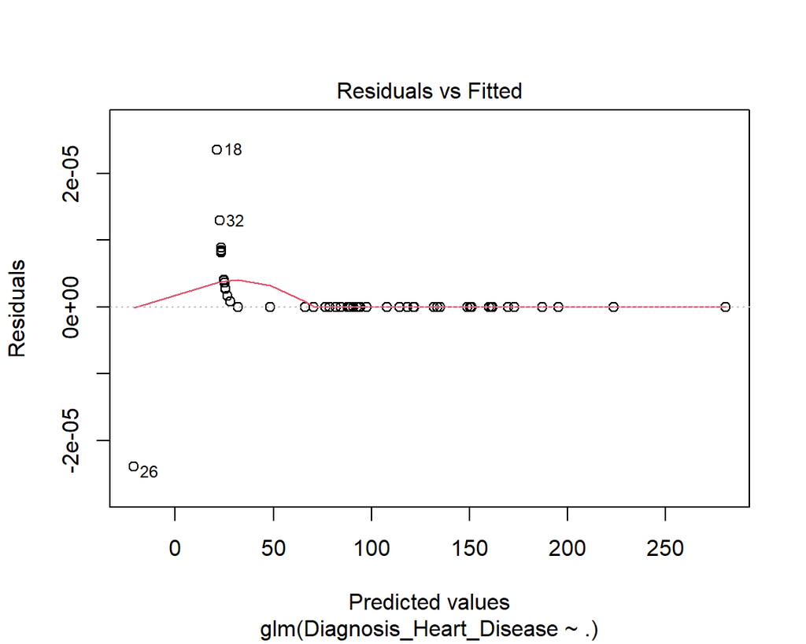

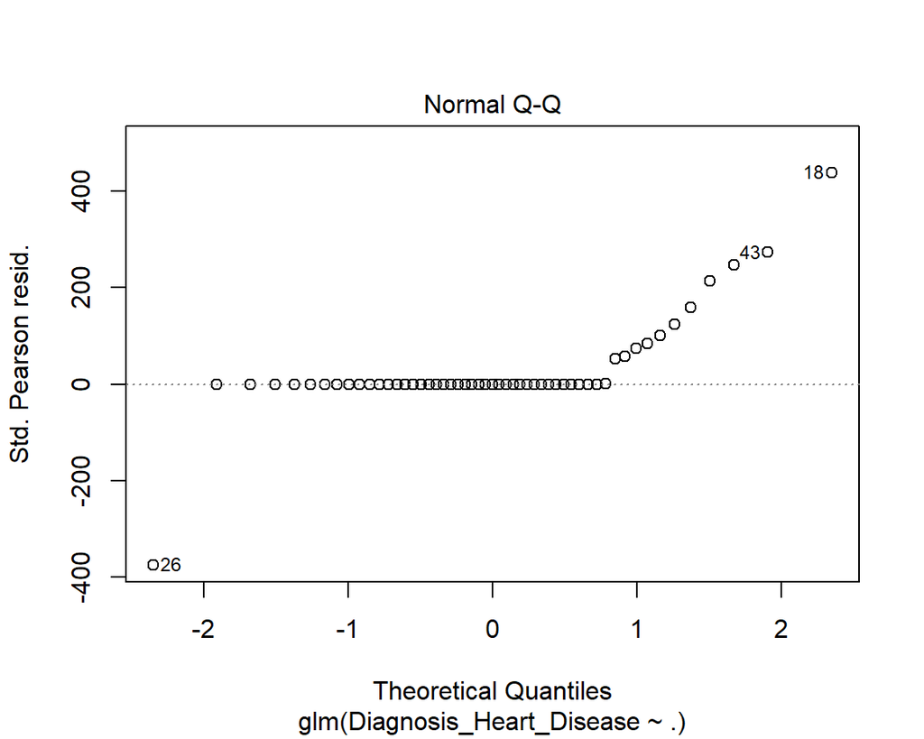

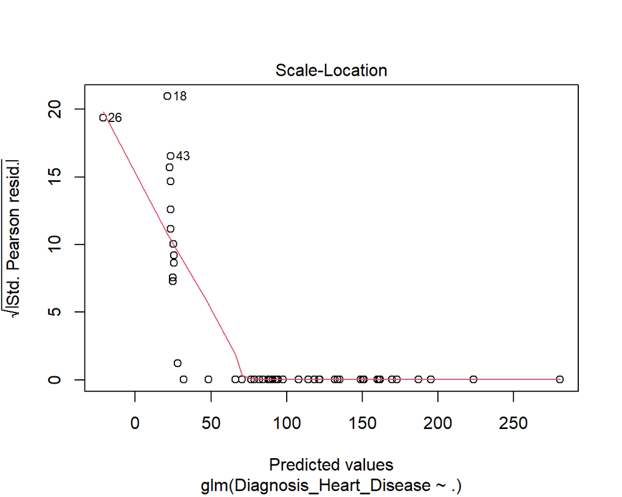

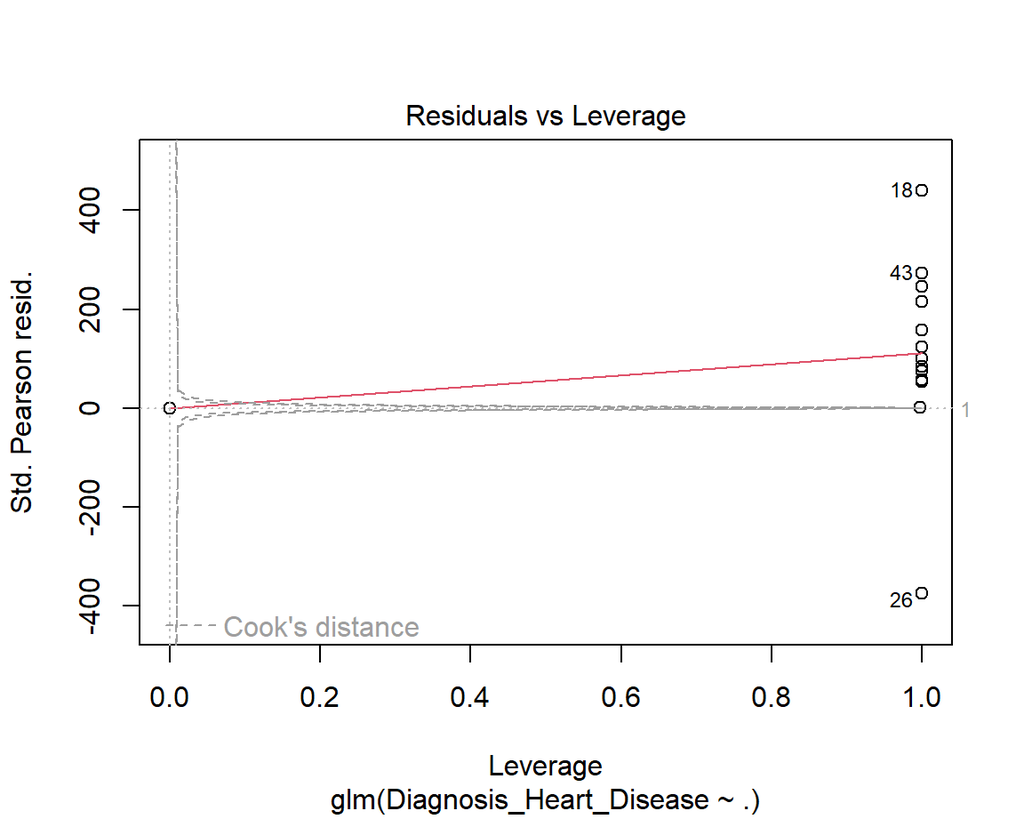